# Population Growth Models

Xin Huang

22 April 2017

In population genetics, we use mathematical models to describe how population grows as time goes on. We can divide these models into two categories–deterministic and stochastic–based on whether we consider random factors or not. If we neglect random factors and assume the population has infinite number of individuals, then we build up determinsitic models. If we can’t neglect random factors because the population has finite number of individuals, which is a more realistic scenario, we have to think about stochastic models.

### Deterministic models

#### Discrete time model

In this model, we assume the generation time is discrete. This means the old generation die out after they give birth to the new generation, like silkworm.

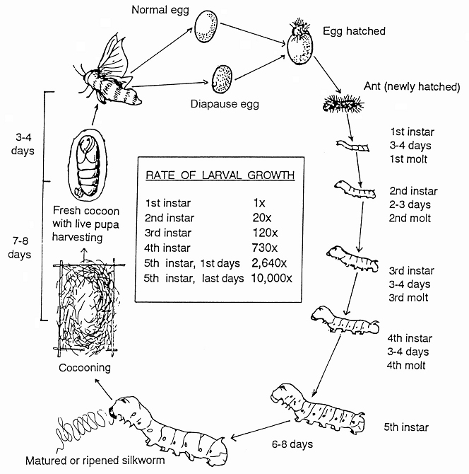

Let $N_t$ be the number of individual in the population at time $t$, and $w$ be the average number of progeny per individual (also the measure of the fitness of an individual), then the number of individual in the population at time $t+1$ is:
$$N_{t+1}=wN_t.$$

Therefore, if $N_0$ is the number of individual in the population at time 0, then
$$N_t=N_0w^t.$$

If there are $k$ types of individuals in the population, and each type has different fitness (they have different number of progeny), then we can replace $w$ with $\bar{w}$, which is the average fitness of individuals in the population. Let $n_k$ be the number of the $k$-th type individual, and $w_k$ be its fitness, then the total number of individual in the population $N=\sum_k n_k$, and the average fitness is:
$$\bar{w}=\frac{\sum_k w_kn_k}{N},$$

and
$$N_{t+1}=\bar{w}N_t.$$